# Baseline PD Scorecard

Logistic Regression With Weight of Evidence

Evan Reynolds

2026-10-01

## Model Summary

0.493

Test Gini

Discrimination on unseen applicants

0.362

Test KS

Separation between the two outcome groups

-0.003

Train/Test Gini Gap

Stability between training and test

0

Decile Reversals

Risk ranking holds across all deciles

## What the Model Predicts

The model estimates each applicant’s probability of repayment difficulty.

0

TARGET = 0

No repayment difficulty

1

TARGET = 1

Repayment difficulty

Dataset-specific default proxy. Not a Basel default definition.

## Pre-Fit Success Criteria

Criteria were defined before model fitting to provide a consistent basis for validation.

≥ 0.45

Test Gini

Minimum discrimination threshold

≤ 0.02

Train/Test Gini Gap

Limits deterioration between training and test

Consistent

Coefficient Signs

Aligned with the expected direction of risk

0

Decile Reversals

Risk rises across successive deciles

## Results Against Criteria

0.493

Test Gini

Criterion ≥ 0.450 · PASS

-0.003

Train/Test Gini Gap

Criterion ≤ 0.020 · PASS

11 of 12

Coefficients negative

Credit logic aligned · PASS

0

Decile Reversals

Criterion = 0 · PASS

The one positive coefficient is Income Type (+0.057, 95% CI -0.03 to 0.14). The interval spans zero, so the coefficient is noted rather than treated as a failed sign.

## Rank Ordering

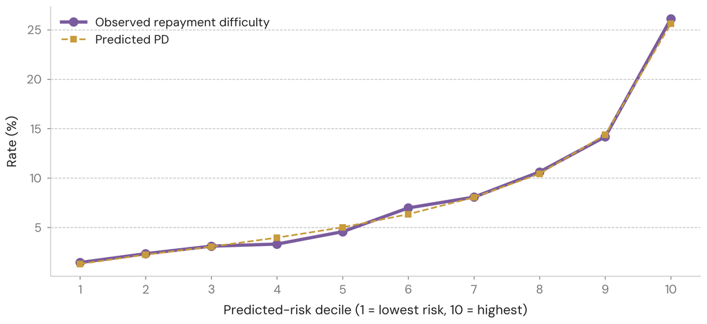

**Observed repayment difficulty increases across all ten predicted-risk deciles, with zero reversals.**

## Model Coefficients

| Feature | Coefficient |
| --- | --- |
| External Credit Score 3 | -0.825 |
| External Credit Score 2 | -0.752 |
| Credit-to-Goods Ratio (LVR) | -0.563 |
| Education | -0.543 |
| External Credit Score 1 | -0.519 |
| Annuity-to-Credit Ratio | -0.432 |
| Organisation Band | -0.388 |
| Job Tenure | -0.367 |
| Regional Rating | -0.352 |
| Goods Price | -0.309 |
| Occupation | -0.281 |
| Income Type | +0.057 |

## Model Limitations

**Target definition.** Repayment difficulty is a dataset-specific proxy, not a Basel default definition.

**External scores.** Model performance depends materially on the external credit-score variables.

**Validation scope.** The model has not undergone production validation. Gender is excluded as a protected attribute, and proxy checks on retained fields are a next step.

## Baseline Established

The logistic scorecard meets the predefined validation criteria and becomes the benchmark for challenger testing.

**Next:** test whether LightGBM provides meaningful performance improvement.